# Project 1

## Step 4: Descriptive and Inferential Statistics

##### 24. Summarize each distribution. As data scientists, be sure to back up these summaries with statistics. (Hint: What are the three things we care about when describing distributions?)

```python
state_data.describe()
```

|  | ACT Participation | ACT Eng | ACT Math | ACT Read | ACT Sci | ACT Comp | SAT Participation | SAT Read-Write | SAT Math | SAT Total |
| --- | --- | --- | --- | --- | --- | --- | --- | --- | --- | --- |
| count | 51.000000 | 51.000000 | 51.000000 | 51.000000 | 51.000000 | 51.000000 | 51.000000 | 51.000000 | 51.000000 | 51.000000 |
| mean | 0.652549 | 20.931373 | 21.182353 | 22.013725 | 21.450980 | 21.519608 | 0.398039 | 569.117647 | 556.882353 | 1126.098039 |
| std | 0.321408 | 2.353677 | 1.981989 | 2.067271 | 1.739353 | 2.020695 | 0.352766 | 45.666901 | 47.121395 | 92.494812 |
| min | 0.080000 | 16.300000 | 18.000000 | 18.100000 | 18.200000 | 17.800000 | 0.020000 | 482.000000 | 468.000000 | 950.000000 |
| 25% | 0.310000 | 19.000000 | 19.400000 | 20.450000 | 19.950000 | 19.800000 | 0.040000 | 533.500000 | 523.500000 | 1055.500000 |
| 50% | 0.690000 | 20.700000 | 20.900000 | 21.800000 | 21.300000 | 21.400000 | 0.380000 | 559.000000 | 548.000000 | 1107.000000 |
| 75% | 1.000000 | 23.300000 | 23.100000 | 24.150000 | 23.200000 | 23.600000 | 0.660000 | 613.000000 | 599.000000 | 1212.000000 |
| max | 1.000000 | 25.500000 | 25.300000 | 26.000000 | 24.900000 | 25.500000 | 1.000000 | 644.000000 | 651.000000 | 1295.000000 |

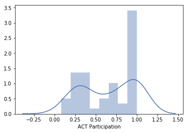

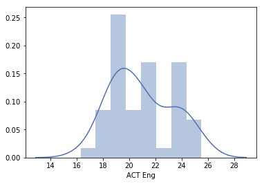

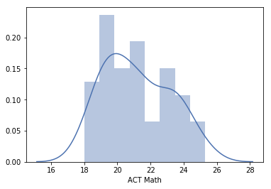

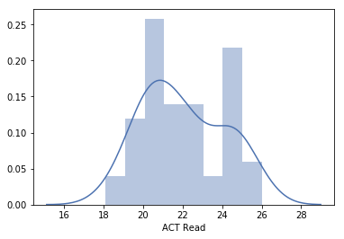

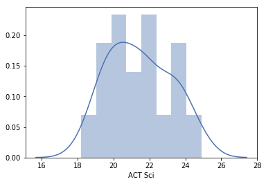

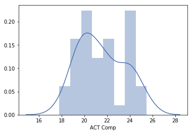

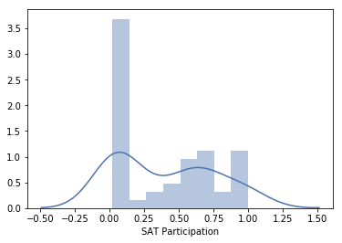

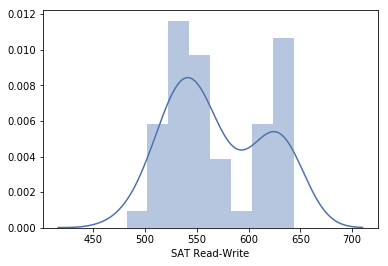

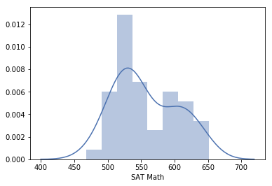

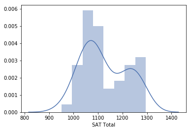

```python
# this for loop creates distribution plots with kernel density estimates
# for each of the numerical series in the dataframe
for column in state_data.describe():
    sns.distplot(state_data[column],bins=8)
    plt.show()
```

```python
# filter data set to show participation rates for ACT/SAT in the 10 lowest SAT-taking states
low_sat = state_data[state_data["SAT Participation"] <= 0.05]
lowSatData = low_sat.sort_values(by="SAT Participation")
lowSatData["SAT Total"].mean()
```

```
1242.0625
```

```python
lowActData = state_data[state_data["ACT Participation"] <= 0.25]
lowActData.describe()
```

|  | ACT Participation | ACT Eng | ACT Math | ACT Read | ACT Sci | ACT Comp | SAT Participation | SAT Read-Write | SAT Math | SAT Total |
| --- | --- | --- | --- | --- | --- | --- | --- | --- | --- | --- |
| count | 5.000000 | 5.000000 | 5.000000 | 5.000000 | 5.000000 | 5.000000 | 5.000000 | 5.000000 | 5.000000 | 5.000000 |
| mean | 0.176000 | 24.220000 | 23.840000 | 24.900000 | 23.780000 | 24.320000 | 0.854000 | 525.400000 | 513.200000 | 1038.600000 |
| std | 0.057706 | 0.729383 | 0.756968 | 0.663325 | 0.645755 | 0.694262 | 0.161338 | 16.562005 | 16.813685 | 32.784143 |
| min | 0.080000 | 23.400000 | 23.300000 | 24.200000 | 23.300000 | 23.700000 | 0.650000 | 503.000000 | 492.000000 | 996.000000 |
| 25% | 0.180000 | 24.000000 | 23.400000 | 24.700000 | 23.400000 | 24.000000 | 0.710000 | 513.000000 | 499.000000 | 1012.000000 |
| 50% | 0.180000 | 24.100000 | 23.400000 | 24.800000 | 23.600000 | 24.100000 | 0.950000 | 532.000000 | 520.000000 | 1052.000000 |
| 75% | 0.210000 | 24.200000 | 24.000000 | 24.800000 | 23.700000 | 24.300000 | 0.960000 | 539.000000 | 524.000000 | 1062.000000 |
| max | 0.230000 | 25.400000 | 25.100000 | 26.000000 | 24.900000 | 25.500000 | 1.000000 | 540.000000 | 531.000000 | 1071.000000 |

1) ACT Participation: This is a left-skewed distribution centered at 65% (.65) with a standard deviation of 0.32. It has a twin-peak PDF (peaks near 0.25 and 1.0).

2) ACT English: The English scores have a nearly-normal distribution, centered around a mean of 20.9 and a standard deviation of 2.35. The presence of a few higher scores (24-26) creates a plateau that prevents this distribution from being "normal."

3) ACT Math: Math scores exhibit a distribution curve closer to a normal distribution, though the bulk of the values occur between 18-22. Its mean is ~21.2, and its standard deviation is 1.98; with more scores below 18 this may have been very near a normal distribution.

4) ACT Reading: These scores behaved much like the English scores, with a plateau around 24 that kept the distribution from appearing almost normal. The mean and standard deviation here are 22.01 and 2.07 respectively.

5) ACT Science: The closest of the four component scores to a normal distribution, the Science scores were quite nicely grouped around the mean of 21.45 with a standard deviation of 1.74, smallest of all the ACT score columns.

7) SAT Participation: This distribution needs more instances of rates between 0.25 and 0.5 to have a hope of being close to normal. As it is, it is a dual-peak curve with peaks close to zero and 0.6, with a mean of 0.398 and a standard deviation of 0.35 - which indicates that schools are more starkly divided on SAT participation than ACT.

8) SAT Verbal (Reading/Writing): This curve, like the SAT participation rates, is double-peaked. Its peaks lie close to its 25th and 75th percentiles (scores of 533 and 613), and its mean and standard deviation are 569 and 45.67.

9) SAT Math: This curve resembles that of the English and Reading ACT component scores: a global peak near the 25th percentile, and a plateau near the 75th. The mean and standard deviation are 557 and 47.12.

##### 25. Summarize each relationship. Be sure to back up these summaries with statistics.

Similarly, ACT composite scores increased in states where the SAT participation rate is high, likely for the same reason: the ACT takers were more likely to be invested in the outcome. States with a sub-25% ACT participation rate showed composite scores 2.5 points above the national average, as well as mean subject scores at least as better (2.5-3.5 points above national average).

Both SAT and ACT average scores experience dips across all subjects when the statewide participation rate for that test is high.

##### 26. Execute a hypothesis test comparing the SAT and ACT participation rates. Use $\alpha = 0.05$. Be sure to interpret your results.

Hypothesis: There's sufficient evidence with the data we have to hypothesize that the means of the ACT and SAT participation rates are markedly different at the state level.

Null (H0)...... mu_act = mu_sat

Alt (Ha)...... mu_act != mu_sat

```python
# save the mean and standard deviations of the participation columns
actmean = state_data["ACT Participation"].mean()
satmean = state_data["SAT Participation"].mean()
act_std = state_data["ACT Participation"].std()
sat_std = state_data["SAT Participation"].std()

# following the Penn State website example (https://onlinecourses.science.psu.edu/stat414/node/268)
# pval is the
pval = (satmean + actmean)/100
x_bar = actmean - satmean
zScore = x_bar / ((pval*(1-pval)*(2/50)) ** 0.5)
zScore
```

```
12.481065022591103
```

At this z-score, we see that the difference in ACT and SAT participation means is over 12 standard deviations away from the mean. Our alpha value of 0.05, split to each tail of the distribution, gives us an alpha of 0.025 on the high end and a z-score multiplier of 1.96. This is laughably small compared to our calculated score of 12.48. This indicates that the alternative hypothesis is definitively true.

##### 27. Generate and interpret 95% confidence intervals for SAT and ACT participation rates.

```python
confidence = 0.95
sat_interval = (satmean - 1.96 * sat_std, satmean + 1.96 * sat_std)
act_interval = (actmean - 1.96 * act_std, actmean + 1.96 * act_std)
print("SAT Participation Confidence Interval: ", sat_interval)
print("ACT Participation Confidence Interval: ", act_interval)
```

```
SAT Participation Confidence Interval:  (-0.293382776805981, 1.08946120817853)
ACT Participation Confidence Interval:  (0.022588516096461175, 1.282509523119225)
```

This is unusual to me - the SAT participation confidence interval ranges beyond the real scope of participation (below 0%, above 100%), which indicates the standard deviation is large enough to introduce significant uncertainty in whether a state participates and to what degree. The ACT interval is similarly large, but doesn't reach 0% on the lower end.

##### 28. Given your answer to 26, was your answer to 27 surprising? Why?

To a degree, yes. Both confidence intervals range past 100% participation and either nearly to, or past, 0% participation. This would insinuate that both participation rates could correspond to the same distribution, which from the data presented does not (on its face) seem to be the case.

##### 29. Is it appropriate to generate correlation between SAT and ACT math scores? Why?

I don't believe that it is appropriate to correlate the two. It's certainly possible to do so, but the demographic differences in the populations that take the SAT or ACT in a given year are significant. In areas where the ACT reigns and the SAT is scarcely taken, the students taking the SAT are often the students invested in attending a school that prioritizes the SAT (East/West Coast, private schools) and thus on average have higher scores.

Meanwhile, when most students in an area take the ACT, there is a prominent portion of the group that takes it and does not score well, which weighs down the average math score. If the data was more granular and detailed, or if participation rates were more even across the board, it might be worth taking correlations between the two.

##### 30. Suppose we only seek to understand the relationship between SAT and ACT data in 2017. Does it make sense to conduct statistical inference given the data we have? Why?

No, it does not make sense to take inferential statistics. While it's possible to take sub-samples of the data set to make other inferences, we risk losing data clarity by sampling and taking means of means.

And, to reiterate an earlier point, the level of detail in the data set is not sufficient in my view to dig more deeply into the relationships. We don't know who the "participants" are, where they're from, what year of high school they are in or how old they are, whether they applied to college or which colleges they applied to. That is just the tip of the iceberg, too. Having a deeper level of detail would help provide insight that can't be inferred: zip code data can be tied to property values can be tied to educational quality (socioeconomic details); county-level test administration data can be examined for metropolitan/rural areas, or areas near/far from universities; and other data that can be used.